# HW6_SOL

Konstantinos Pasvantis

2023-01-03

Φορτώνουμε τα απαραίττητα πακέτα που θα χρειαστούμε

```r
library(stringr)
library(ggmosaic)
library(splitstackshape)
library(tidyverse)
library(spData)
library(gghighlight)
library(ggtext)
library(sf)
```

## Ερώτημα 1

Πριν προσωρήσουμε πρέπει να φορτώσουμε το dataset και να κάνουμε την κατάλληλη προεπεξεργασία.

```r
album<-read.csv('album.csv')
head(album)
```

```
##                                   genre                       artist
## 1                 Avant-Garde,Classical                Kavina, Lydia
## 2                 Avant-Garde,Classical              Rockmore, Clara
## 3                 Avant-Garde,Classical              Rockmore, Clara
## 4 Avant-Garde,Classical,Electronic,Jazz Riley, Terry; Kronos Quartet
## 5        Avant-Garde,Classical,Pop-Rock             GalΓ\241s, Diamanda
## 6        Avant-Garde,Classical,Pop-Rock             GalΓ\241s, Diamanda
##                                                      album
## 1 (1999) Music From The Ether_ Original Works For Theremin
## 2                           (1987) The Art of the Theremin
## 3              (2006) Clara Rockmore's Lost Theremin Album
## 4                        (1985) Cadenza on the Night Plain
## 5                    (2003) Defixiones, Will and Testament
## 6                                 (2003) La Serpenta canta
```

Χωρίζουμε την στήλη album σε δύο διακριτές στήλες με ονόματα title και year. Και στην συνέχεια μετατρέπουμε τις τιμές της στήλης year σε αριθμούς, αφού βγάλουμε τις παρενθέσεις.

```r
album<-album%>%separate(album,c('year','title'),sep="^\\S*\\K\\s+")
album$year<-str_sub(album$year,2,-2)%>%as.numeric()
head(album)
```

```
##                                   genre                       artist year
## 1                 Avant-Garde,Classical                Kavina, Lydia 1999
## 2                 Avant-Garde,Classical              Rockmore, Clara 1987
## 3                 Avant-Garde,Classical              Rockmore, Clara 2006
## 4 Avant-Garde,Classical,Electronic,Jazz Riley, Terry; Kronos Quartet 1985
## 5        Avant-Garde,Classical,Pop-Rock             GalΓ\241s, Diamanda 2003
## 6        Avant-Garde,Classical,Pop-Rock             GalΓ\241s, Diamanda 2003
##                                               title
## 1 Music From The Ether_ Original Works For Theremin
## 2                           The Art of the Theremin
## 3              Clara Rockmore's Lost Theremin Album
## 4                        Cadenza on the Night Plain
## 5                    Defixiones, Will and Testament
## 6                                 La Serpenta canta
```

Στην συνέχεια επιλέγουμε από το dataset album τις στήλες που μας ενδιαφέρουν, δηλαδή αυτή που περιλαμβάνει το όνομα των καλλιτεχνών και αυτή με τα είδη κάθε άλμπουμ.

```r
artists<-album%>%select(c(2,1))
```

Χρησιμοποιώντας την εντολή cSplit της χωρίζουμε τα είδη των album σε όσα είναι καταγεγραμένα, διαλέγουμε μόνο τις πρώτες τρεις στήλες και έτσι έχουμε καταλήξει με ένα καινούργιο dataset το οποίο έχει μόνο τα ονόματα των καλλιτεχνών και τα δύο κυριότερα είδη μουσικής που παίζουν.

```r
artists<-artists%>%cSplit('genre',sep=',',direction = 'wide' )%>%select(c(1,2,3))%>%rename(primary='genre_1',secondary='genre_2')
artists<-distinct(artists,artist,.keep_all = TRUE)
head(artists)
```

```
##                          artist     primary     secondary
## 1:                Kavina, Lydia Avant-Garde     Classical
## 2:              Rockmore, Clara Avant-Garde     Classical
## 3: Riley, Terry; Kronos Quartet Avant-Garde     Classical
## 4:             GalΓ\241s, Diamanda Avant-Garde     Classical
## 5:                  Frahm, Nils Avant-Garde    Electronic
## 6:              Henriksen, Arve Avant-Garde International
```

Χωρίζουμε στην συνέχεια και τα είδη μουσικής από το αρχικό μας dataset για να μας βοηθήσει αργότερα.

```r
album<-album%>%cSplit('genre',sep=',',direction = 'wide' )
```

## Ερώτημα 1

### (α)

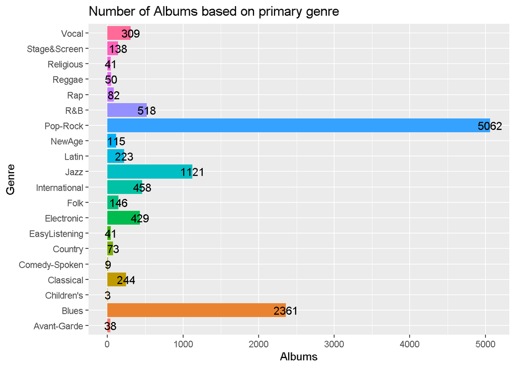

```r
album%>%
  ggplot(aes(x=genre_1,fill=genre_1))+
  geom_bar()+
  coord_flip()+
  geom_text(stat='count',aes(label=..count..))+
  ggtitle("Number of Albums based on primary genre")+xlab("Genre") + ylab("Albums") + theme(legend.position = "none")
```

### (β)

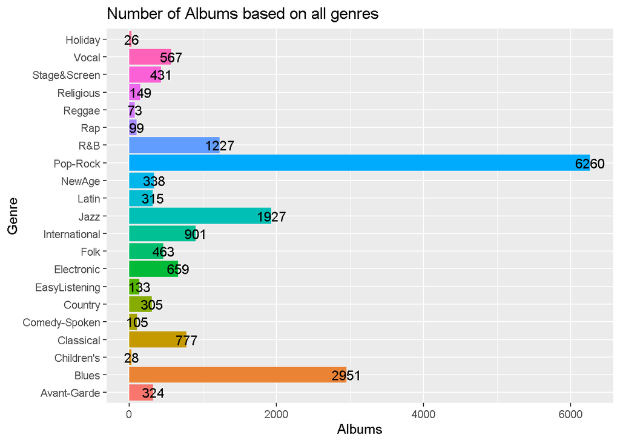

```r
album%>%
  pivot_longer(cols = c(4:11))%>%
  na.omit()%>%
  ggplot(aes(x=value,fill=value))+
  geom_bar()+
  coord_flip()+
  geom_text(stat='count',aes(label=..count..))+
  ggtitle("Number of Albums based on all genres")+xlab("Genre") + ylab("Albums") + theme(legend.position = "none")
```

### (γ)

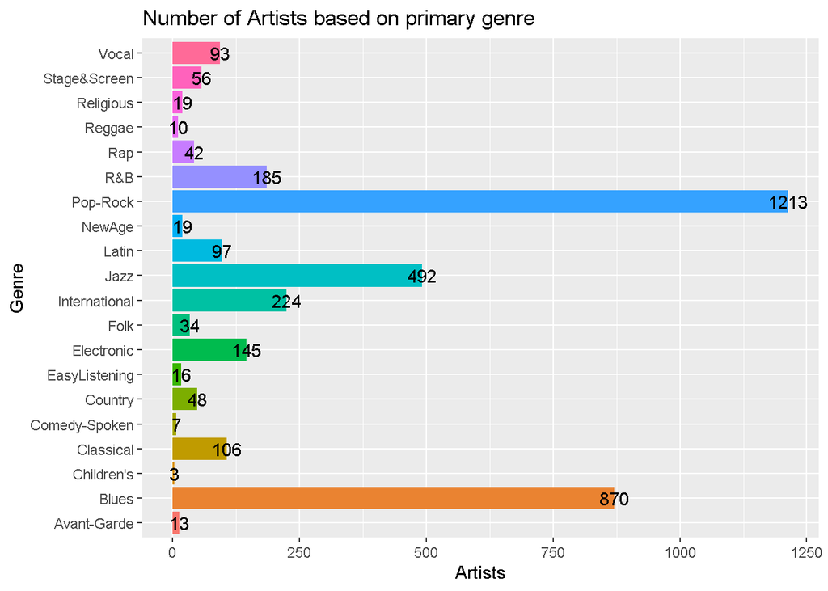

```r
album%>%
  distinct(artist,.keep_all = TRUE)%>%
  ggplot(aes(x=genre_1,fill=genre_1))+
  geom_bar()+
  coord_flip()+
  geom_text(stat='count',aes(label=..count..))+ggtitle("Number of Artists based on primary genre")+xlab("Genre") + ylab("Artists") +
  theme(legend.position = "none")
```

### (δ)

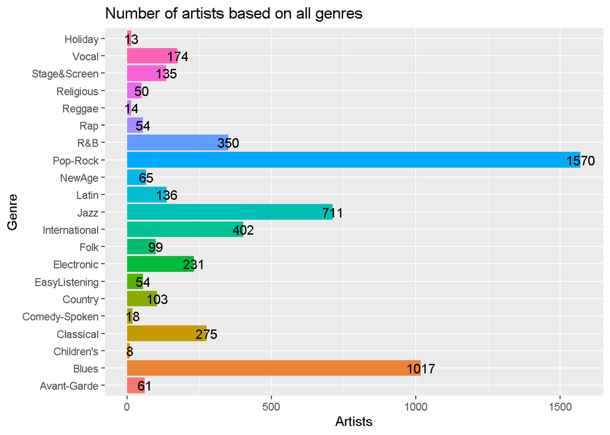

```r
album%>%
  distinct(artist,.keep_all = TRUE)%>%
  pivot_longer(cols = c(4:11))%>%
  na.omit()%>%
  ggplot(aes(x=value,fill=value))+
  geom_bar()+
  coord_flip()+
  geom_text(stat='count',aes(label=..count..),)+ggtitle("Number of artists based on all genres")+xlab("Genre") + ylab("Artists") + theme(legend.position = "none")
```

## Ερώτημα 2

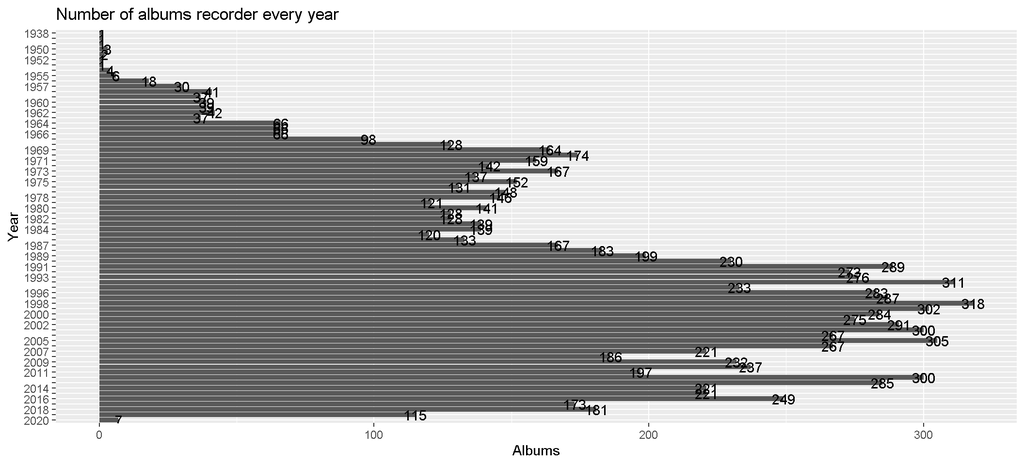

```r
album%>%
  ggplot(aes(x=reorder(year,-year)))+
  geom_bar()+
  coord_flip()+
  geom_text(stat='count',aes(label=..count..))+
  ggtitle("Number of albums recorder every year")+xlab("Year") + ylab("Albums")+ theme(axis.text = element_text(size = 9))+scale_x_discrete(guide = guide_axis(check.overlap = TRUE))
```

## Ερώτημα 3

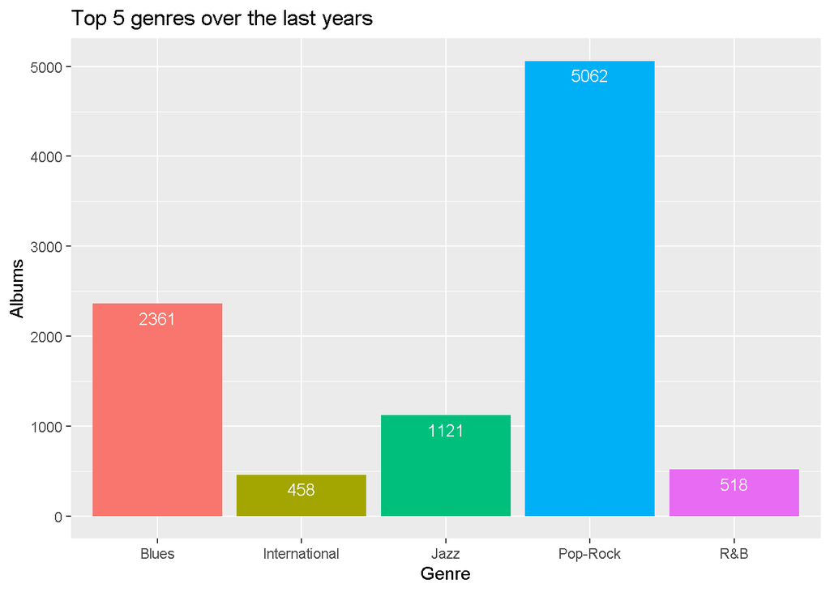

```r
album%>%
  group_by(genre_1)%>%
  mutate(count_name_occurr = n())%>%
  arrange(-count_name_occurr)%>%
  distinct(genre_1,.keep_all = TRUE)%>%
  head(n=5)%>%
  ggplot(aes(x=genre_1,y=count_name_occurr,fill=genre_1))+geom_bar(stat='identity')+
  ggtitle("Top 5 genres over the last years")+xlab("Genre") + ylab("Albums") + theme(legend.position = "none")+
  geom_text(aes(label=count_name_occurr),vjust=1.6, color="white", size=3.5)
```

## Ερώτημα 4

Εδώ επειδή έχουμε πολλά είδη μουσικής το mosaic plot δεν εμφανίζεται τόσο καθαρά όσο θα έπρεπε, αλλά μπορούμε να δούμε ποιά είδη έχουν μεγάλη συσχέτιση μεταξύ τους διασθητικά.

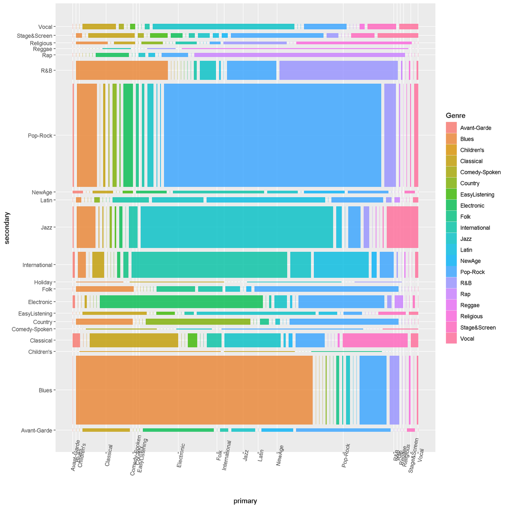

```r
artist_new<-artists%>%
  mutate(secondary=coalesce(secondary,primary))

artist_new%>%
  ggplot()+geom_mosaic(aes(x=product(primary,secondary),fill=primary))+
  theme(axis.text.x = element_text(angle = 80))+
  coord_flip()+
  guides(fill=guide_legend(title="Genre"))
```

## Ερώτημα 5

Εδώ πέρα δημιουργούμε ένα διάνυσμα από το dataset world, το οποίο περιέχει μόνο τα ονόματα των χωρών και τις γεωμετρίες τους.

```r
country_names<-world$name_long%>%st_drop_geometry()
```

Με αυτόν τον κώδικα τώρα βλέπουμε ποιά ονόματα χωρών εμφανίζονται σε τίτλους album, και δημιουργοόυμε στο dataset world μία νέα στήλη η οποία περιέχει το πόσες φορές εμφανίζονται τα ονόματα των χωρών συνολικά σε τίτλους album.

```r
result<-data.frame(country_names, t(sapply(paste0('\\b', country_names, '\\b'), function(x) {
  tmp <- grepl(x, album$title)
  c(perc = mean(tmp) * 100,
    Freq = sum(tmp))
})), row.names = NULL)

world$Freq_countries=result$Freq
head(world)
```

```
## Simple feature collection with 6 features and 11 fields
## Geometry type: MULTIPOLYGON
## Dimension:     XY
## Bounding box:  xmin: -180 ymin: -18.28799 xmax: 180 ymax: 83.23324
## Geodetic CRS:  WGS 84
## # A tibble: 6 x 12
##   iso_a2 name_long conti~1 regio~2 subre~3 type  area_~4     pop lifeExp gdpPe~5
##   <chr>  <chr>     <chr>   <chr>   <chr>   <chr>   <dbl>   <dbl>   <dbl>   <dbl>
## 1 FJ     Fiji      Oceania Oceania Melane~ Sove~  1.93e4  8.86e5    70.0   8222.
## 2 TZ     Tanzania  Africa  Africa  Easter~ Sove~  9.33e5  5.22e7    64.2   2402.
## 3 EH     Western ~ Africa  Africa  Northe~ Inde~  9.63e4 NA         NA       NA
## 4 CA     Canada    North ~ Americ~ Northe~ Sove~  1.00e7  3.55e7    82.0  43079.
## 5 US     United S~ North ~ Americ~ Northe~ Coun~  9.51e6  3.19e8    78.8  51922.
## 6 KZ     Kazakhst~ Asia    Asia    Centra~ Sove~  2.73e6  1.73e7    71.6  23587.
## # ... with 2 more variables: geom <MULTIPOLYGON [arc_degree]>,
## #   Freq_countries <dbl>, and abbreviated variable names 1: continent,
## #   2: region_un, 3: subregion, 4: area_km2, 5: gdpPercap
```

Και τώρα σχηματίζουμε τον χάρτη στον οποίο οι χώρες εμφανίζονται χρωματισμένες ανάλογα με το πόσα album περιέχουν το όνομά τους. Μπορούμε να δούμε ότι η Ιαπωνία έχει αναφερθεί σε 20 τίτλους album!

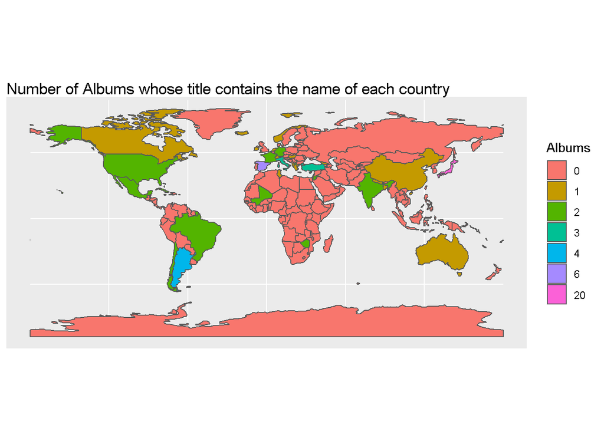

```r
world%>%ggplot()+geom_sf(aes(fill=as.factor(Freq_countries)))+guides(fill=guide_legend(title="Albums"))+ggtitle("Number of Albums whose title contains the name of each country")+theme(plot.title = element_textbox_simple())
```

## Ερώτημα 6

Στο πρώτο γράφημα παρουσιάζουμε τους 10 καλύτερους καλλιτέχνες στην κατάταξη, με βάση τον αριθμό των album που έχουν δημιουργήσει ανά τα χρόνια.

```r
top_artists_based_on_album<-album%>%
  group_by(artist)%>%
  summarise(number_of_albums=n())%>%
  arrange(-number_of_albums)%>%head(n=10)
head(top_artists_based_on_album)
```

```
## # A tibble: 6 x 2
##   artist              number_of_albums
##   <chr>                          <int>
## 1 Rolling Stones, The               62
## 2 Coltrane, John                    59
## 3 Depeche Mode                      59
## 4 Dylan, Bob                        56
## 5 Helloween                         51
## 6 Baez, Joan                        50
```

Για να κάνουμε πιο όμοφο το γράφημα, φτιάχνουμε καλύτερα την μορφή με την οποία εμφανίζεται το όνομα των καλλιτεχνών.

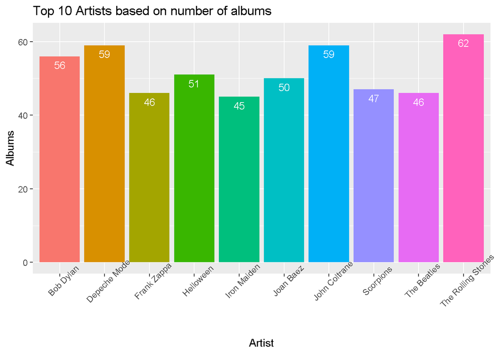

```r
artist_names=strsplit(top_artists_based_on_album$artist,',')

top_artists_based_on_album$artist=unlist(lapply(artist_names,
              function(x) paste(x[1:length(x) %% 2 == 0],
                                x[1:length(x) %% 2 != 0])))

top_artists_based_on_album%>%
  ggplot(aes(x=artist,y=number_of_albums,fill=artist))+
  geom_col()+
  ggtitle("Top 10 Artists based on number of albums")+
  xlab("Artist") +
  ylab("Albums")+
  theme(legend.position = "none")+
  geom_text(aes(label=number_of_albums),vjust=1.6, color="white", size=3.5)+
  theme(axis.text.x = element_text(angle = 45))
```

Στο δεύτερο γράφημα παρουσιάζεται οι 10 καλύτερες χρονίες όσον αφορά τον αριθμό των album που παράχθηκαν από διακεκριμένους καλλιτέχνες.

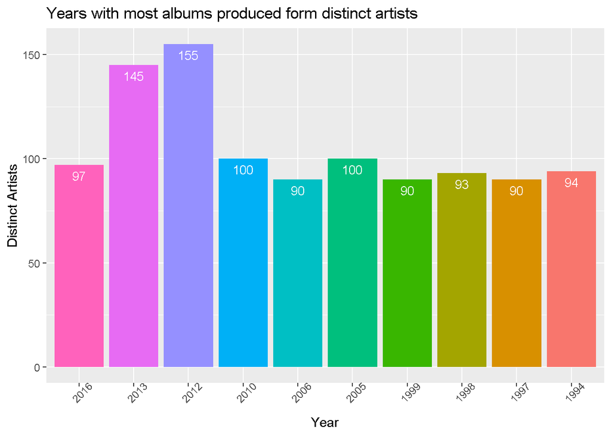

```r
album%>%
  distinct(artist,.keep_all = TRUE)%>%
  group_by(year)%>%
  summarise(number_of_distinct_artists=n())%>%
  arrange(-number_of_distinct_artists)%>%head(n=10)%>%
  ggplot(aes(x=reorder(year,-year),y=number_of_distinct_artists,fill=as.factor(year)))+
  geom_col()+
  ggtitle("Years with most albums produced form distinct artists")+xlab("Year") + ylab("Distinct Artists") +
  theme(legend.position = "none")+geom_text(aes(label=number_of_distinct_artists),vjust=1.6, color="white", size=3.5)+
  theme(axis.text.x = element_text(angle = 45))
```

Και τέλος, σε αυτό το γράφημα εμφανίζουμε τις χρονίες που δημιουργήθηκαν album που στον τίτλο τους περιήχαν την λέξη αγάπη (love)

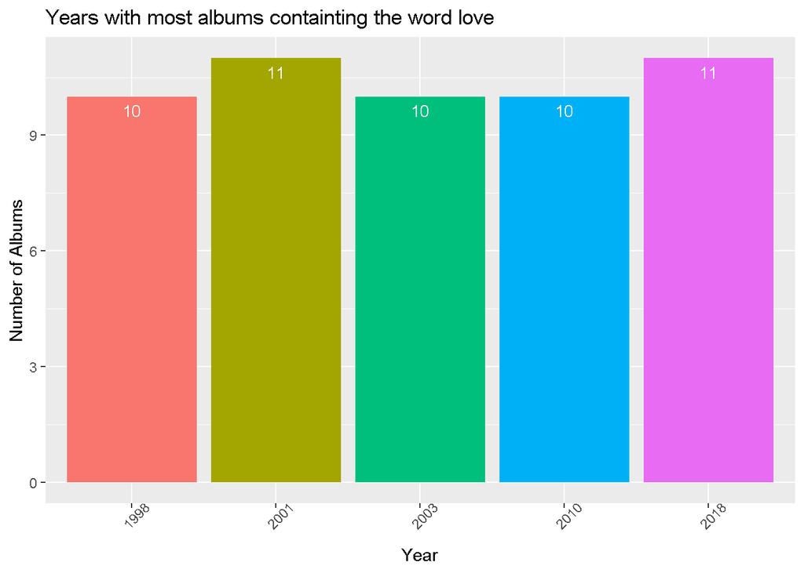

```r
album%>%
  filter(str_detect(title,'Love'))%>%
  group_by(year)%>%
  summarise(number_of_album_containing_word=n())%>%
  arrange(-number_of_album_containing_word)%>%head(n=5)%>%
  ggplot(aes(x=reorder(year,year),y=number_of_album_containing_word,fill=as.factor(year)))+
  geom_col()+ggtitle("Years with most albums containting the word love ")+xlab("Year") + ylab("Number of Albums") + theme(legend.position = "none")+
  geom_text(aes(label=number_of_album_containing_word),vjust=1.6, color="white", size=3.5)+
  theme(axis.text.x = element_text(angle = 45))
```